# Homework

```r
library(tidyverse)
library(CodeClanData)
library(skimr)
library(GGally) # library for creating those insane correllelograms :)
```

```r
glimpse(backpack)
```

```
Rows: 100
Columns: 9
$ backpack_weight <int> 9, 8, 10, 6, 8, 5, 8, 4, 5, 2, 8, 21, 11, 11, 12, 11, 13, 6, 10, 5, 20, 14, 11, 15, 1…
$ body_weight     <int> 125, 195, 120, 155, 180, 240, 170, 185, 130, 120, 135, 160, 170, 170, 125, 175, 145, …
$ ratio           <dbl> 0.0720000, 0.0410256, 0.0833333, 0.0387097, 0.0444444, 0.0208333, 0.0470588, 0.021621…
$ back_problems   <int> 1, 0, 1, 0, 0, 0, 0, 1, 0, 0, 0, 0, 0, 1, 1, 0, 1, 0, 1, 0, 0, 1, 0, 0, 0, 1, 0, 0, 0…
$ major           <fct> Bio, Philosophy, GRC, CSC, EE, History, CM, ARCE, Bio, Bio, Bus, ME, CPE, CPE, CS, CP…
$ year            <int> 3, 5, 4, 6, 2, 0, 3, 5, 4, 5, 3, 5, 4, 4, 3, 4, 4, 3, 3, 3, 2, 2, 5, 5, 3, 1, 4, 2, 2…
$ sex             <fct> Female, Male, Female, Male, Female, Male, Male, Female, Female, Female, Female, Male,…
$ status          <fct> U, U, U, G, U, G, U, U, U, U, U, U, U, U, U, U, U, U, U, U, U, U, U, U, U, U, U, U, U…
$ units           <int> 13, 12, 14, 0, 14, 0, 15, 18, 14, 8, 15, 12, 16, 16, 12, 16, 16, 16, 17, 14, 16, 12, …
```

```r
names(backpack)
```

```
[1] "backpack_weight" "body_weight"     "ratio"           "back_problems"   "major"           "year"
[7] "sex"             "status"          "units"
```

```r
skim(backpack)
```

```
── Data Summary ────────────────────────
                           Values
Name                       backpack
Number of rows             100
Number of columns          9
_______________________
Column type frequency:
  factor                   3
  numeric                  6
________________________
Group variables            None
```

|  | skim_variable | n_missing | complete_rate | ordered | n_unique | top_counts |
| --- | --- | --- | --- | --- | --- | --- |
| 1 | major | 0 | 1 | FALSE | 41 | Bio: 9, Bus: 8, LS: 7, ME: 6 |
| 2 | sex | 0 | 1 | FALSE | 2 | Fem: 55, Mal: 45 |
| 3 | status | 0 | 1 | FALSE | 2 | U: 97, G: 3 |

|  | skim_variable | n_missing | complete_rate | mean | sd | p0 | p25 | p50 | p75 | p100 | hist |
| --- | --- | --- | --- | --- | --- | --- | --- | --- | --- | --- | --- |
| 1 | backpack_weight | 0 | 1 | 11.66000000 | 5.76513380 | 2.000 | 8.00000000 | 11.0000000 | 14.2500000 | 35.000000 | ▅▇▂▁▁ |
| 2 | body_weight | 0 | 1 | 153.05000000 | 29.39744200 | 105.000 | 130.00000000 | 147.5000000 | 170.0000000 | 270.000000 | ▆▇▂▁▁ |
| 3 | ratio | 0 | 1 | 0.07712546 | 0.03663729 | 0.016 | 0.05120967 | 0.0714286 | 0.0962963 | 0.181034 | ▆▇▆▃▁ |
| 4 | back_problems | 0 | 1 | 0.32000000 | 0.46882617 | 0.000 | 0.00000000 | 0.0000000 | 1.0000000 | 1.000000 | ▇▁▁▁▃ |
| 5 | year | 0 | 1 | 3.20000000 | 1.39262125 | 0.000 | 2.00000000 | 3.0000000 | 4.0000000 | 6.000000 | ▃▆▇▆▆ |
| 6 | units | 0 | 1 | 14.27000000 | 2.80639601 | 0.000 | 13.00000000 | 15.0000000 | 16.0000000 | 19.000000 | ▁▁▁▇▆ |

```r
backpack_data <- backpack
```

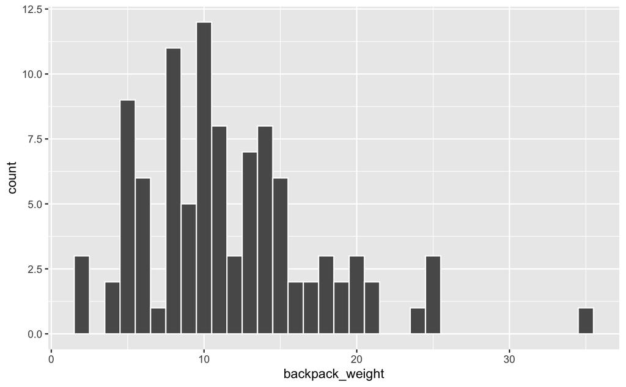

```r
backpack_data %>%
ggplot((aes( x= backpack_weight))) +
 geom_histogram(binwidth=1, boundary = 0.5, colour = "white")
```

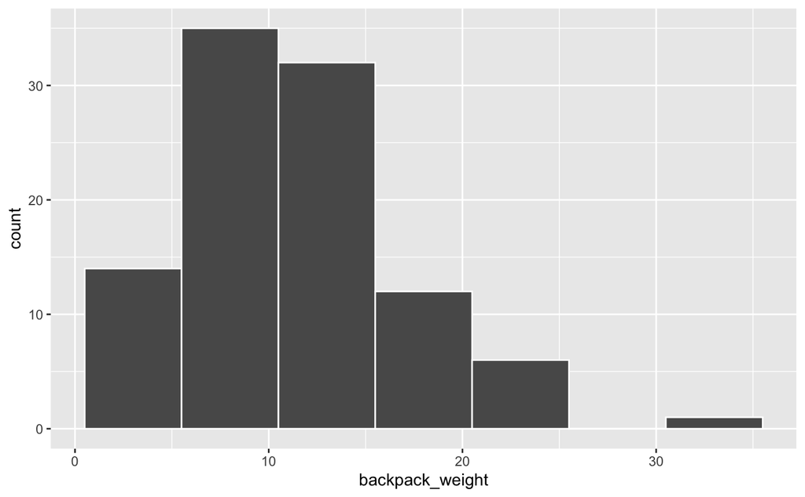

```r
backpack_data %>%
ggplot((aes( x= backpack_weight))) +
 geom_histogram(binwidth=5, boundary = 0.5, colour = "white")
```

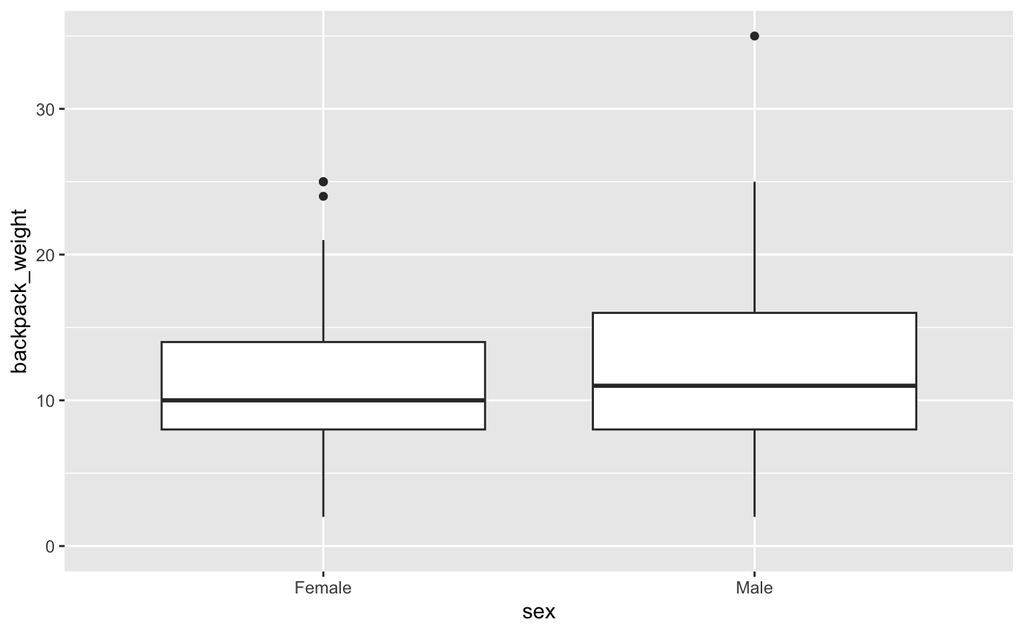

```r
backpack_data %>%
ggplot((aes(x = sex, y = backpack_weight))) +
 geom_boxplot() +
 ylim(0, max(backpack_data$backpack_weight))
```

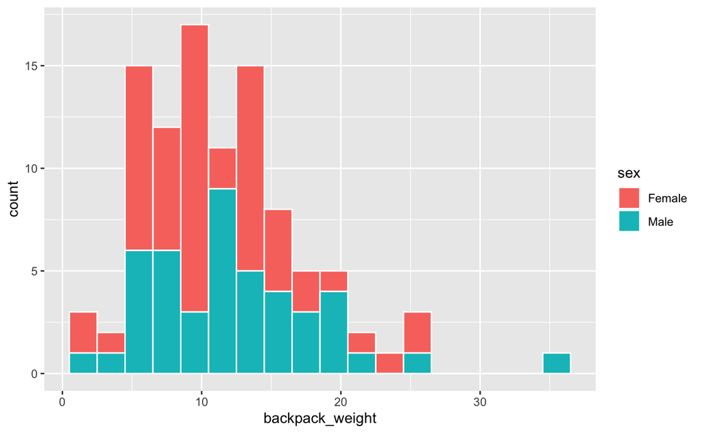

```r
backpack_data %>%
ggplot((aes( x= backpack_weight, fill = sex))) +
 geom_histogram(binwidth= 2, boundary = 0.5, colour = "white")
```

Male students on average, had slightly heavier bags. The range of backpack weights carried by male and female students was similar.

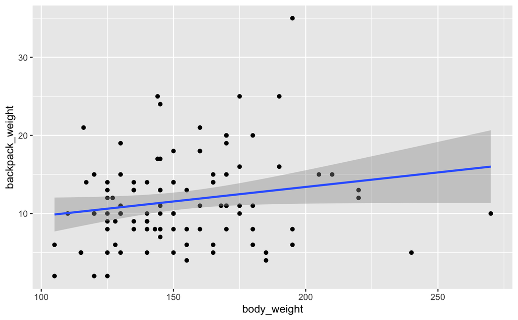

```r
backpack_data %>%
ggplot(aes(x = body_weight, y = backpack_weight)) +
 geom_point() +
 geom_smooth(method = "lm")
```

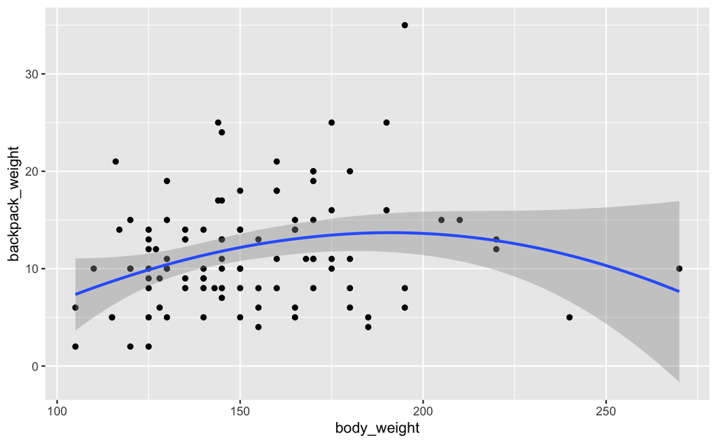

```r
backpack_data %>%
ggplot(aes(x = body_weight, y = backpack_weight)) +
 geom_point() +
 geom_smooth(method = "loess", span = 1)
```

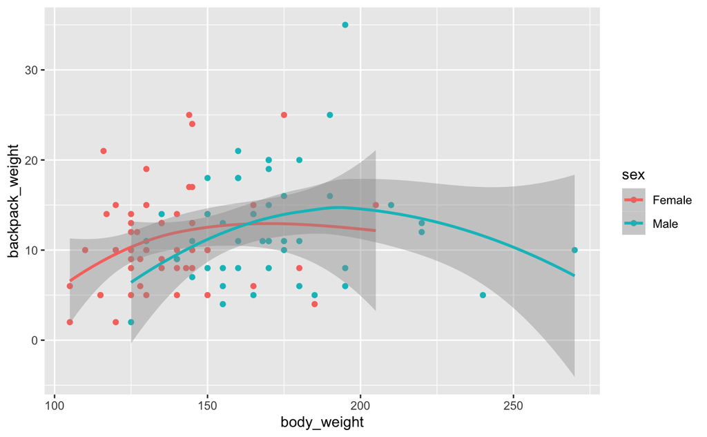

```r
backpack_data %>%
ggplot(aes(x = body_weight, y = backpack_weight, colour = sex)) +
 geom_point() +
 geom_smooth(method = "loess", span = 1)
```

There could be a number of reasons why backpack and body weight might vary. A larger person has larger clothes and therefore their backpack weight would be positively correlated with body weight. In most able-bodied people, strength could also be related to bodyweight, and in a group scenario stronger people may be required to carry more. At very high bodyweights fitness may have an impact and so the largest people may adjust by choosing to carry a lighter backpack.

From the data, there does not appear to be a linear relationship between body weight and backpack weight. Fitting a more complex smoother could indicate that backpack weight initially increases with body weight but then decreases again. A similar pattern is observed when fitting to male and female groups separately.

However the confidence bands on both the linear fit and loess smoother are wide and many points lie outside of these bands. I dont think it’s possible to have any confidence in these fitted trends.

```r
backpack_data %>%
  select(back_problems) %>%
  group_by(back_problems) %>%
  summarise(count = n(), prop=100*(n()/nrow(backpack_data)), tot = nrow(backpack_data))
```

| back_problems | count | prop | tot |
| --- | --- | --- | --- |
| 0 | 68 | 68 | 100 |
| 1 | 32 | 32 | 100 |

```r
group_by(backpack_data,sex) %>%
          summarise(count = n())
```

| sex | count |
| --- | --- |
| Female | 55 |
| Male | 45 |

```r
backpack_data %>%
  select(back_problems, sex) %>%
  group_by(sex, back_problems) %>%
  summarise(count = n(), prop=100*(n()/nrow(backpack_data)), tot = nrow(backpack_data)) %>%
  arrange(desc(sex))
```

| sex | back_problems | count | prop | tot |
| --- | --- | --- | --- | --- |
| Male | 0 | 37 | 37 | 100 |
| Male | 1 | 8 | 8 | 100 |
| Female | 0 | 31 | 31 | 100 |
| Female | 1 | 24 | 24 | 100 |

```r
backpack_data <-  rowid_to_column(backpack_data)
```

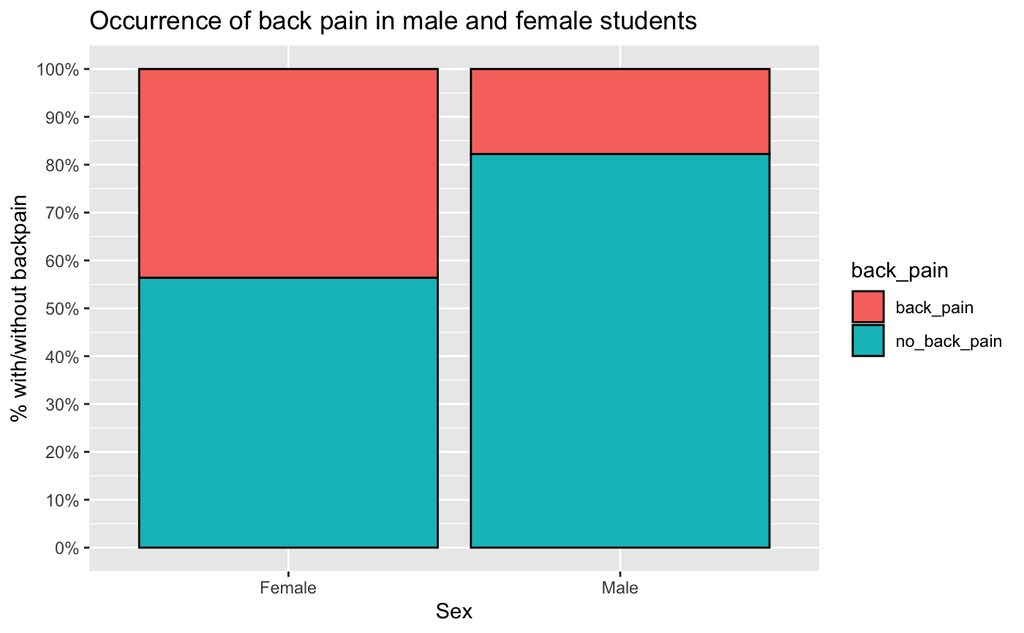

```r
backpack_data %>%
mutate(back_pain = ifelse(back_problems == 1,
                          "back_pain", "no_back_pain")) %>%
ggplot(aes(x = sex, fill = back_pain)) +
geom_bar(position = "fill", colour = "black") +
labs(y = "% with/without backpain",
     x = "Sex",
     title = "Occurrence of back pain in male and female students") +
scale_y_continuous(breaks=c(seq(0, 1, by = 0.1)),labels = scales::percent)
```

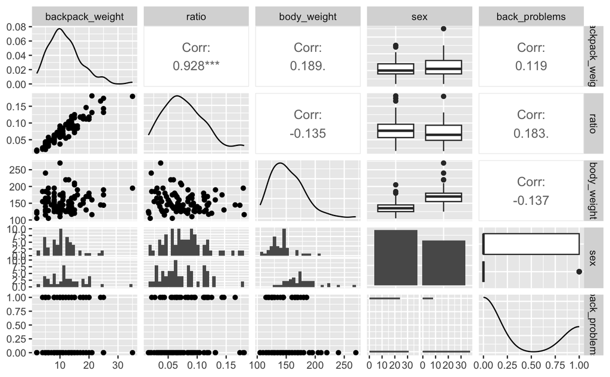

```r
select(backpack_data, backpack_weight, ratio, body_weight, sex, back_problems) %>%
ggpairs()
```

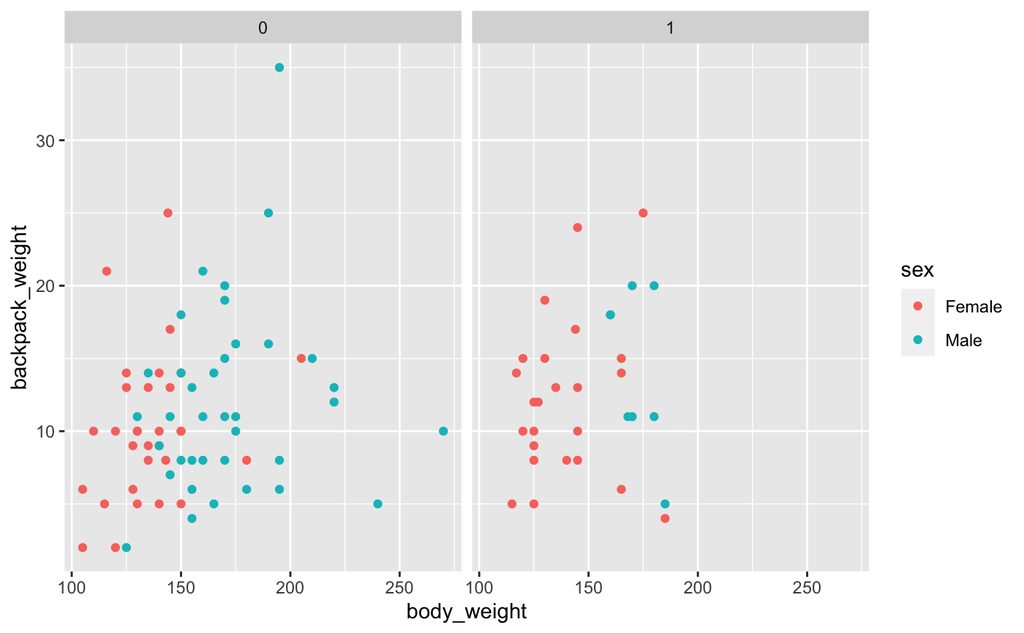

```r
backpack_data %>%
ggplot(aes(x = body_weight, y = backpack_weight, colour = sex)) +
 geom_point() +
 facet_grid(~back_problems)
```

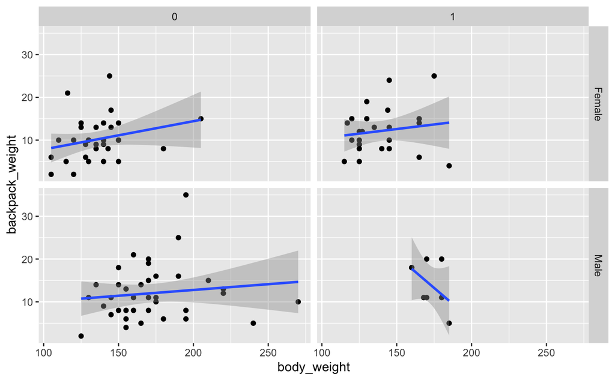

```r
backpack_data %>%
ggplot(aes(x = body_weight, y = backpack_weight)) +
 geom_point() +
 geom_smooth(method="lm") +
 facet_grid(sex ~ back_problems)
```

Im not sure I can see any meaningful relationship here? Maybe for males with backpain, there is an inverse relationship between backpack_weight and bodyweight. For higher body_weights there is a tendency for backpack_weight to be lower?

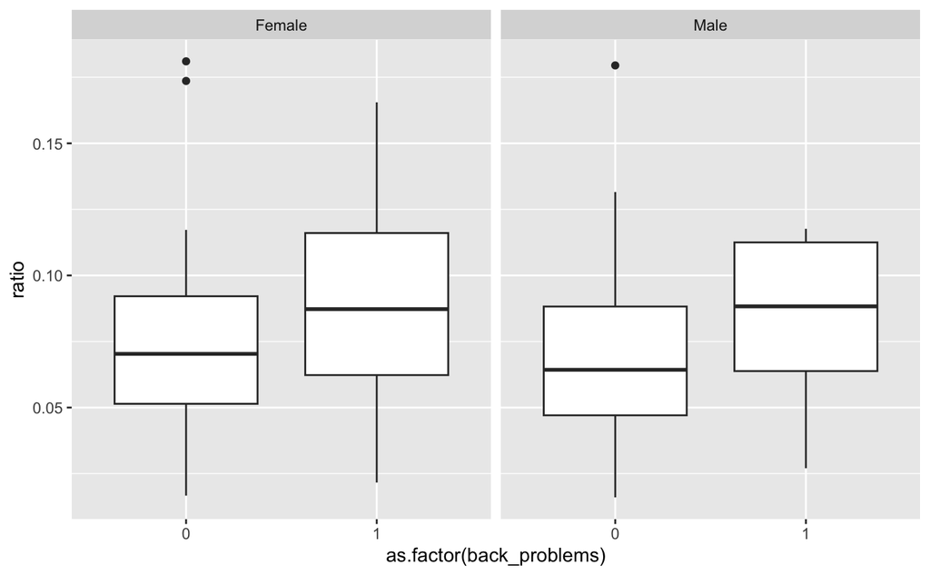

```r
backpack_data %>%
  ggplot(aes(x = as.factor(back_problems), y = ratio)) +
  geom_boxplot() +
  facet_grid(~sex)
```

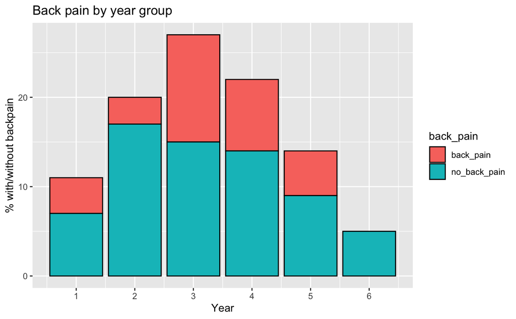

```r
backpack_data %>%
filter(year >0) %>%
mutate(back_pain = ifelse(back_problems == 1,
                          "back_pain", "no_back_pain")) %>%
ggplot(aes(x = year, fill = back_pain)) +
geom_bar(position = "stack" , colour = "black") +
labs(y = "% with/without backpain",
     x = "Year",
     title = "Back pain by year group") +
scale_x_continuous(breaks=c(1:6))
```

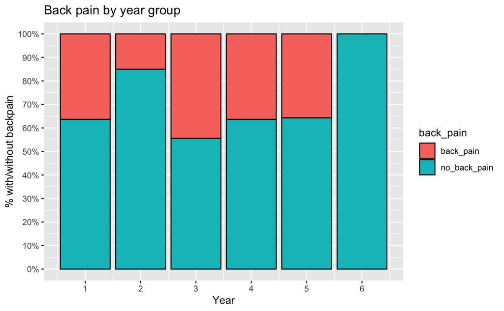

```r
backpack_data %>%
filter(year >0) %>%
mutate(back_pain = ifelse(back_problems == 1,
                          "back_pain", "no_back_pain")) %>%
ggplot(aes(x = year, fill = back_pain)) +
geom_bar(position = "fill", colour = "black") +
labs(y = "% with/without backpain",
     x = "Year",
     title = "Back pain by year group") +
scale_x_continuous(breaks=c(1:6)) +
scale_y_continuous(breaks=c(seq(0, 1, by = 0.1)),labels = scales::percent)
```

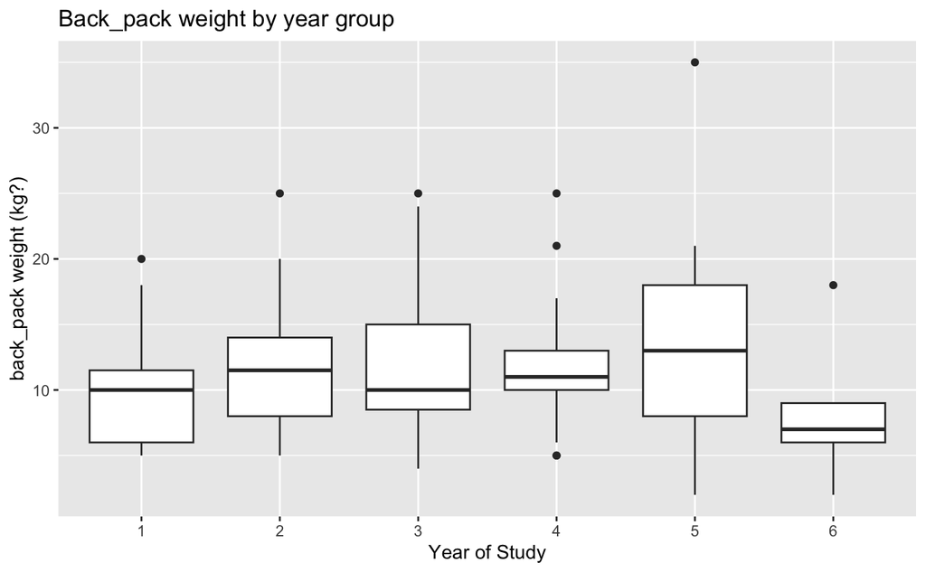

```r
backpack_data %>%
filter(year > 0) %>%
ggplot(aes(x = as.factor(year), y = backpack_weight)) +
geom_boxplot() +
labs(y = "back_pack weight (kg?)",
     x = "Year of Study",
     title = "Back_pack weight by year group")
```

Back pack weight by year group? Possibly an increase in average backpack weight from year 1 - year 5 and then a decrease?

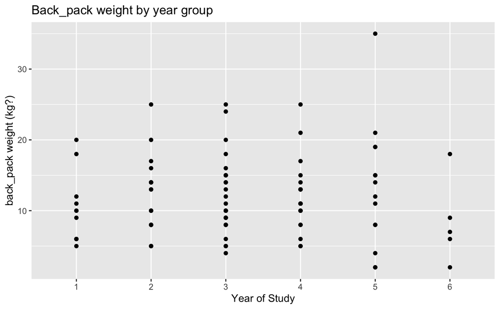

```r
backpack_data %>%
filter(year > 0) %>%
ggplot(aes(x = as.factor(year), y = backpack_weight)) +
geom_point() +
labs(y = "back_pack weight (kg?)",
     x = "Year of Study",
     title = "Back_pack weight by year group")
```

Looking at it like this makes me think that the sample is small and the patterns seen in the boxplot may not be significant.